# Stable Isotopes - Time and Seasonality

Nicole LaRoche

11/4/2019

# Introduction

I am working on sea otter whisker analysis over time from the root to the tip of the whisker. As my analysis is not complete, this is includes 29 sea otters as a population between Klawock and Naukati on Prince of Wales Island. Sea otter whiskers were collected from June 26- August 6, 2019.

# Analysis

First, loading programs and files. Otter ID should be read as a factor.

```r
library(ggplot2)
library(dplyr)
library(ggthemes)
library(scales)

#load whisker data
whisker <- read.csv("whiskers.csv")
whisker$OtterID<-as.character(whisker$OtterID)
oddotter <- read.csv("oddotter.csv")
oddotter$OtterID<-as.factor(oddotter$OtterID)
oddotter$Run<-as.factor(oddotter$Run)



#load prey data
si.prey <- read.csv("sifinal.csv")
```

#### Data Cleaning - Temp until final decision is made for the odd otter

Otter 163532 has very odd values, while it is being re-run I have seperated out the values and am going to make the whisker file without this sea otter.

```r
whisker<- filter(whisker, OtterID != "163532")
```

## Results

Here is each individual sea otter from the root to the tip for Carbon in Teal and Nitrogen in Red.

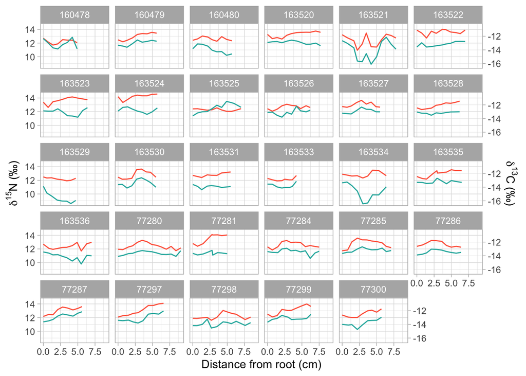

### Odd otter graphs - for reference

#### Carbon

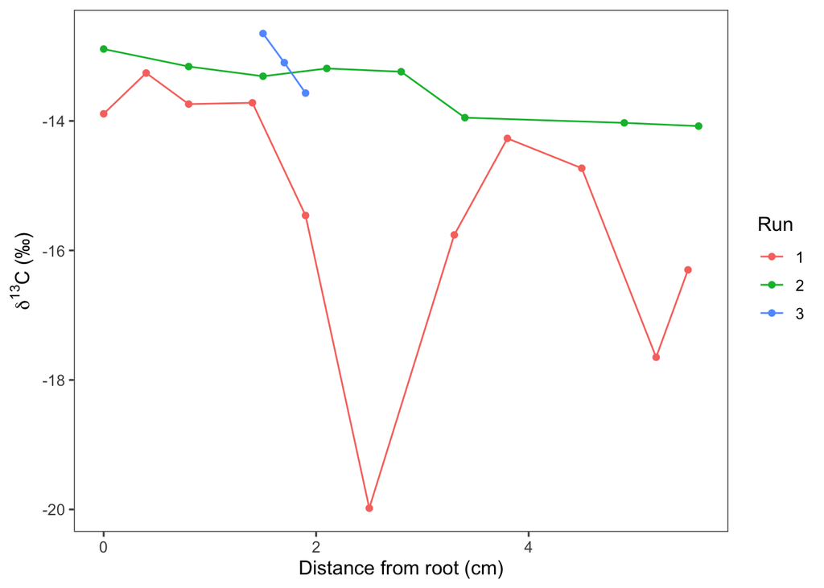

#### Nitrogen

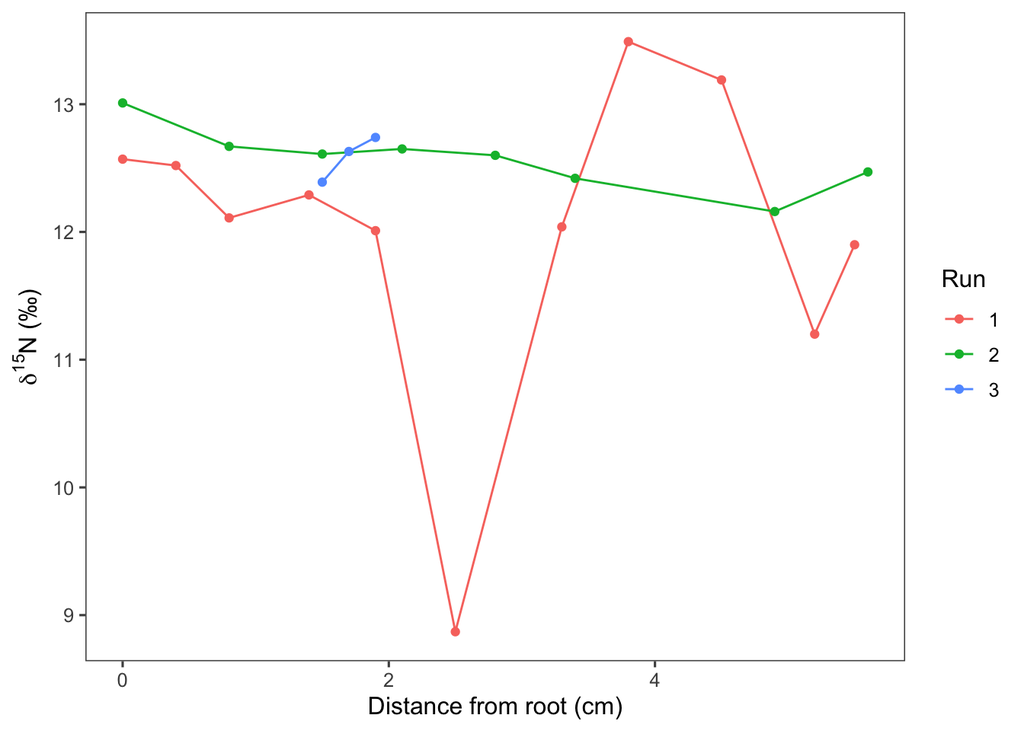

## Seasons

#### Carbon

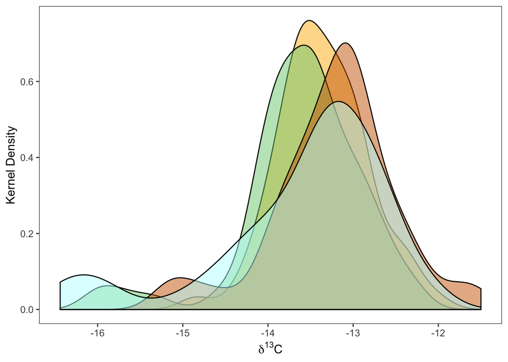

#### Nitrogen

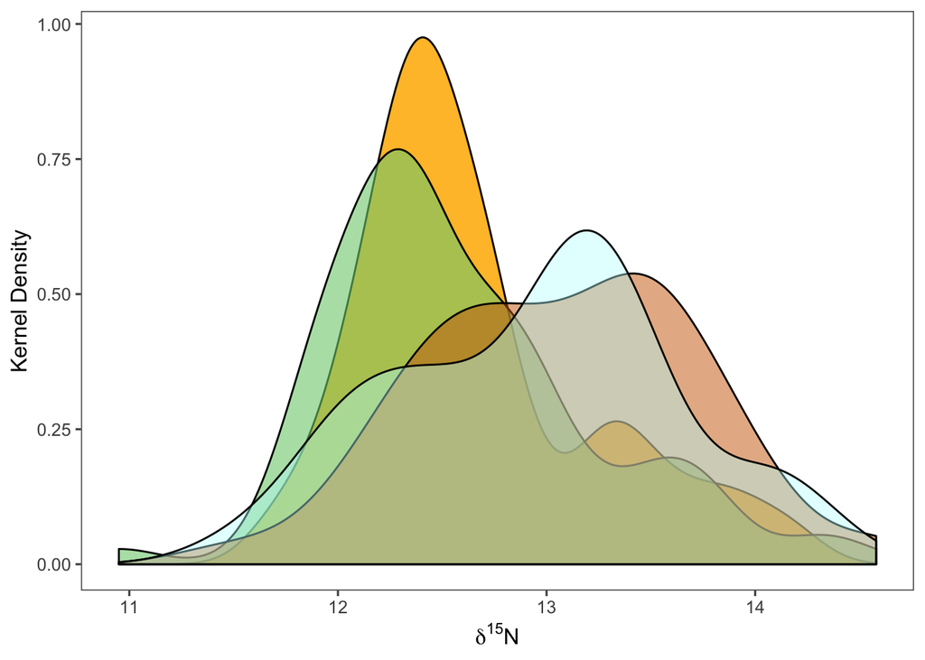

The graphs above are ok, but too messy for a paper, and the kernel density is not what I want to talk about, so here are some boxplots of the same data.

#### Carbon

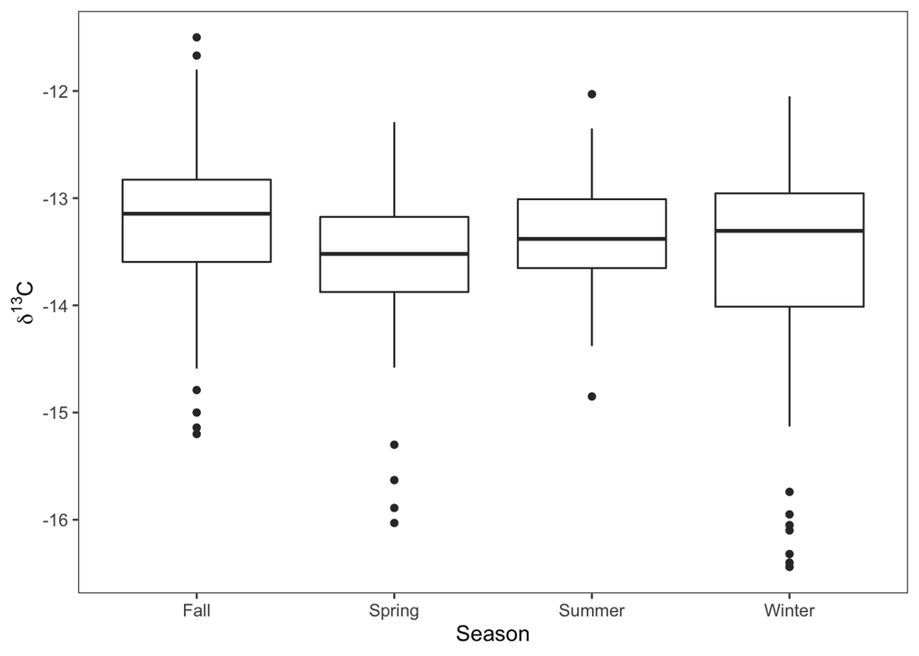

#### Nitrogen

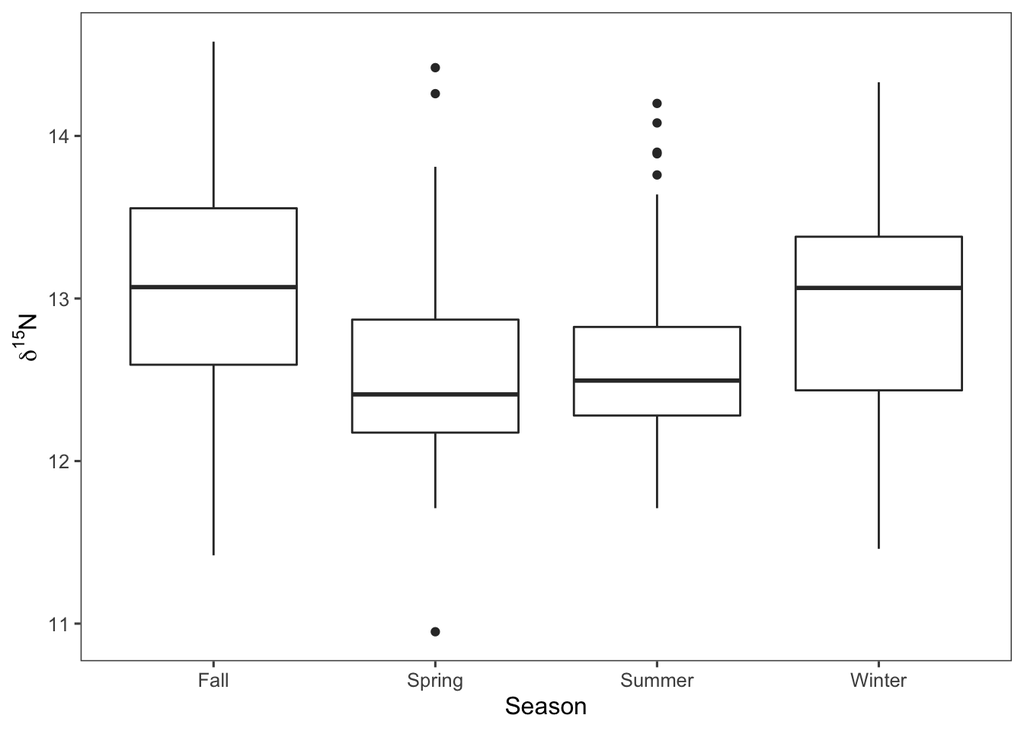

## Stats for Seasons

#### Anova

```r
cseason.aov <- aov(C~Season, data = whisker)
summary(cseason.aov)
```

```
##              Df Sum Sq Mean Sq F value  Pr(>F)
## Season        3   7.36  2.4537   4.072 0.00744 **
## Residuals   285 171.73  0.6026
## ---
## Signif. codes:  0 '***' 0.001 '**' 0.01 '*' 0.05 '.' 0.1 ' ' 1
```

```r
nseason.aov <- aov(N~Season, data = whisker)
summary(nseason.aov)
```

```
##              Df Sum Sq Mean Sq F value   Pr(>F)
## Season        3  11.62   3.875    9.56 4.92e-06 ***
## Residuals   285 115.52   0.405
## ---
## Signif. codes:  0 '***' 0.001 '**' 0.01 '*' 0.05 '.' 0.1 ' ' 1
```

Season for both C and N are significant.

#### Pairwise test for seasons

```r
pairwise.t.test(x=whisker$C, g=whisker$Season, p.adj="none")
```

```
##
##  Pairwise comparisons using t tests with pooled SD
##
## data:  whisker$C and whisker$Season
##
##        Fall   Spring Summer
## Spring 0.0041 -      -
## Summer 0.2997 0.0708 -
## Winter 0.0041 0.9503 0.0740
##
## P value adjustment method: none
```

```r
pairwise.t.test(x=whisker$N, g=whisker$Season, p.adj="none")
```

```
##
##  Pairwise comparisons using t tests with pooled SD
##
## data:  whisker$N and whisker$Season
##
##        Fall    Spring  Summer
## Spring 7.5e-06 -       -
## Summer 0.00015 0.50560 -
## Winter 0.25492 0.00051 0.00554
##
## P value adjustment method: none
```

Nitrogen: Spring/Fall, Spring/Winter, Summer/Fall, and Winter/Summer are significant, which is how I originally matched up the seasons.

```r
pairwise.t.test(x=whisker$C, g=whisker$Season, p.adj="bonferroni")
```

```
##
##  Pairwise comparisons using t tests with pooled SD
##
## data:  whisker$C and whisker$Season
##
##        Fall  Spring Summer
## Spring 0.025 -      -
## Summer 1.000 0.425  -
## Winter 0.024 1.000  0.444
##
## P value adjustment method: bonferroni
```

```r
pairwise.t.test(x=whisker$N, g=whisker$Season, p.adj="bonferroni")
```

```
##
##  Pairwise comparisons using t tests with pooled SD
##
## data:  whisker$N and whisker$Season
##
##        Fall    Spring  Summer
## Spring 4.5e-05 -       -
## Summer 0.00089 1.00000 -
## Winter 1.00000 0.00305 0.03324
##
## P value adjustment method: bonferroni
```

```r
pairwise.t.test(x=whisker$C, g=whisker$Season, p.adj="holm")
```

```
##
##  Pairwise comparisons using t tests with pooled SD
##
## data:  whisker$C and whisker$Season
##
##        Fall  Spring Summer
## Spring 0.024 -      -
## Summer 0.599 0.283  -
## Winter 0.024 0.950  0.283
##
## P value adjustment method: holm
```

```r
pairwise.t.test(x=whisker$N, g=whisker$Season, p.adj="holm")
```

```
##
##  Pairwise comparisons using t tests with pooled SD
##
## data:  whisker$N and whisker$Season
##
##        Fall    Spring  Summer
## Spring 4.5e-05 -       -
## Summer 0.00074 0.50983 -
## Winter 0.50983 0.00203 0.01662
##
## P value adjustment method: holm
```

#### Tukey HSD

```r
TukeyHSD(aov(C~Season, data=whisker))
```

```
##   Tukey multiple comparisons of means
##     95% family-wise confidence level
##
## Fit: aov(formula = C ~ Season, data = whisker)
##
## $Season
##                       diff        lwr         upr     p adj
## Spring-Fall   -0.375258216 -0.7107751 -0.03974132 0.0214541
## Summer-Fall   -0.136372549 -0.4755954  0.20285031 0.7267207
## Winter-Fall   -0.367307692 -0.6951567 -0.03945868 0.0211470
## Summer-Spring  0.238885667 -0.1014955  0.57926687 0.2689859
## Winter-Spring  0.007950524 -0.3210969  0.33699792 0.9999125
## Winter-Summer -0.230935143 -0.5637605  0.10189026 0.2787493
```

```r
TukeyHSD(aov(N~Season, data=whisker))
```

```
##   Tukey multiple comparisons of means
##     95% family-wise confidence level
##
## Fit: aov(formula = N ~ Season, data = whisker)
##
## $Season
##                      diff         lwr        upr     p adj
## Spring-Fall   -0.48594288 -0.76111827 -0.2107675 0.0000441
## Summer-Fall   -0.41393791 -0.69215276 -0.1357231 0.0008529
## Winter-Fall   -0.11869658 -0.38758313  0.1501900 0.6645859
## Summer-Spring  0.07200497 -0.20715990  0.3511698 0.9095921
## Winter-Spring  0.36724630  0.09737689  0.6371157 0.0028444
## Winter-Summer  0.29524133  0.02227337  0.5682093 0.0282038
```

Tukey’s gives similar as Bonferroni and Holm. There are significant values here, but really - the main takeaway needs to be that these means are only .3-.5. which is VERY SMALL.

### Biplot by season

Making mean values for Prey and adding in TDFs for prey

```r
si.mean <-si.prey %>%
  group_by(PreyCat) %>%
  summarise(Cmean=mean(Cnorm), Nmean=mean(N), Csd=sd(Cnorm), Nsd=sd(N),
            Cse=sd(Cnorm)/sqrt(length(Cnorm)), Nse=sd(N)/sqrt(length(N)))
si.mean<-si.mean[-1,] #removing blank
si.mean<-si.mean[-6,] #removing stars

si.mean$Ctdf<-si.mean$Cmean+2
si.mean$Ntdf<-si.mean$Nmean+2.8
```

#### Biplot with sea otters separated by season (error bars are standard error)

Folling Newsome et al. 2009, this is how they portrayed their data. I don’t like that some of the sea otter points fall outside of the prey, but I do like that the graph is a tighter x-axis.

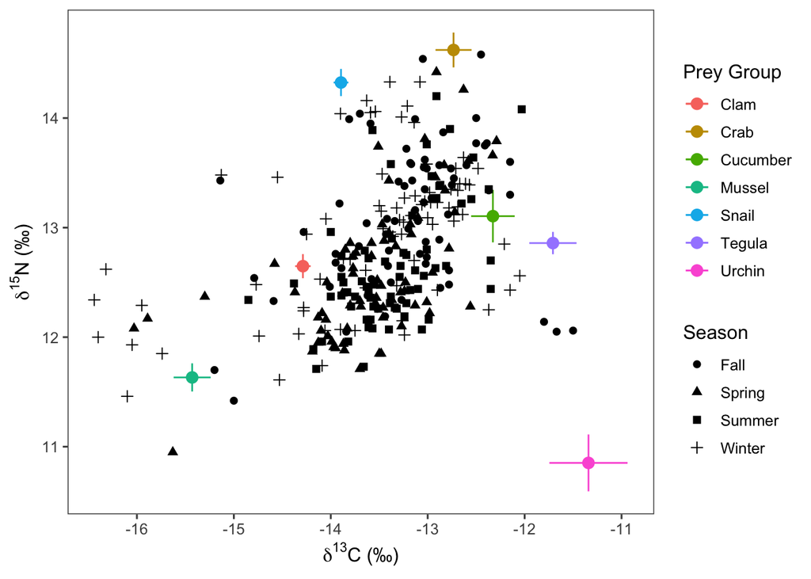

#### Biplot in BW

this is in case there is a requrement for a black and white figure, I’m open to feedback on what would make things stand out more.

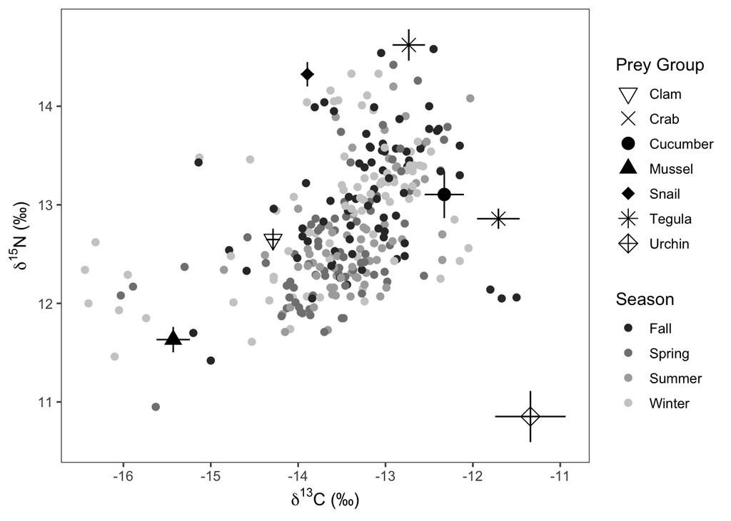

#### Biplot with sea otters separated by season (error bars are standard dev)

This is the plot I prefer, as it shows all points are within one sd of the prey means.

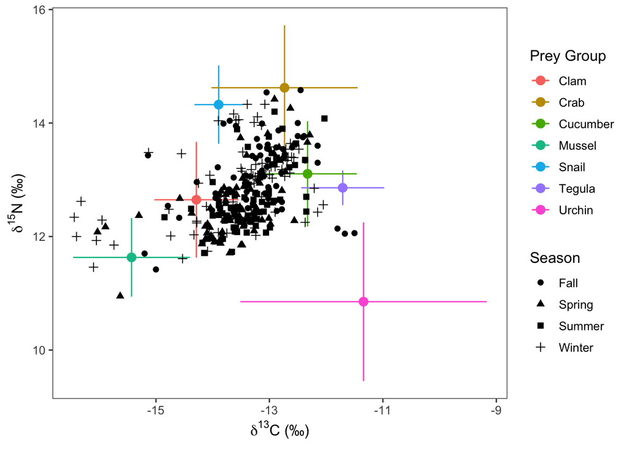

## Mixing Model Results

#### Loading data and prepping for graphing

I made the seasons facors so they will show in order of the months of the year and not alphabetically.

```r
#load prey data
mix.mod <- read.csv("mix_season.csv")

mix.mod$Season<-factor(mix.mod$Season , levels=c("Spring", "Summer", "Fall", "Winter"))
```

### Box and whisker stand in for the moment

I would like this to be a box and whisker plot separated similar to what I have below, but I didn’t save all the correct files from the output, and so am rerunning the model.

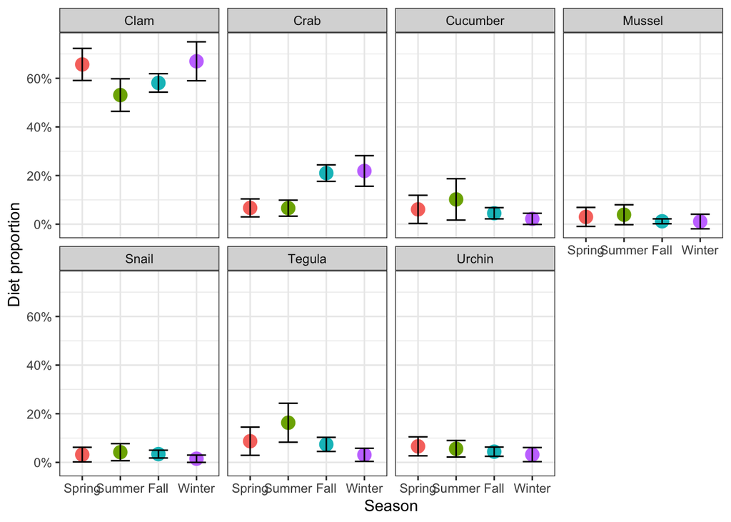